# Notebook

## 연봉 상위 1000개 기업 및 업종 분석

- 연봉 상위 10위권 기업중 증권사 기업이 5개
- 공기업 및 공공기관에 포함된 기업이 가장 多
- 업종별 평균 연봉은 은행이 가장 높다.

## 데이터 요약

- **연봉 상위 1000개 기업(companyDf)** :  
  출처 : 잡코리아, 2018년 기준 연봉 및 직원 수  
  http://www.jobkorea.co.kr/

**numWorkerInc** : 1년간 사원수 증가율

|  | income | industry | name | numWorker | rank |
| --- | --- | --- | --- | --- | --- |
| 0 | 24082 | 제약·보건·바이오 | 셀트리온헬스케어 | 97 | 1 |
| 1 | 19674 | 자동차·조선·철강·항공 | LG | 119 | 2 |
| 2 | 19038 | 자동차·조선·철강·항공 | GS | 25 | 3 |
| 3 | 18927 | none | 에이티넘인베스트 | 22 | 4 |
| 4 | 17344 | 은행·금융 | 비엔피파리바증권 | 66 | 5 |

## 기업들의 연봉 분포

연봉이 커질수록 기업의 수가 감소하는 histogram의 형태

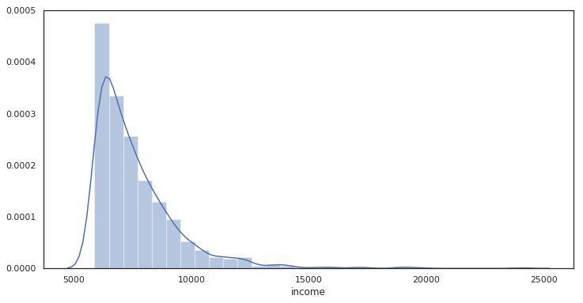

## 연봉 순위 top10

- **셀트리온헬스케어**가 평균 연봉 2억4082만원으로 1위
- **증권사**의 비율이 50% 차지

[interactive chart not shown]

## 업종별 기업 수 top10

- **공기업 및 공공기관**에 속한 기업이 187개로 압도적인 1위  
  대체적으로 높은 연봉이 높은 기업이 많으며 워라밸이 좋아 최근 취업시장에서 높은 선호도를 가지고 있다.

[interactive chart not shown]

## 업종별 연봉 boxplot

- median 값은 은행이 및 금융 업종이 9283만원으로 가장 높음
- 제약,보건 및 바이오 업종의 경우 중앙값은 10위에 위치했지만, 셀트리온 등 이상치가 많아 평균은 높은 순위에 들 것으로 예상

[interactive chart not shown]

## 업종별 직원 수 평균

- **제조업** 분야(자동차, 전기, 반도체 등)의 직원수가 대체로 높음
- **캐피탈 및 대출** 분야의 경우 평균직원수가 231명으로 다른 업종들에 비해 압도적으로 낮은 직원수를 가지고 있음 이는 **은행 및 금융** 과 비슷한 업종이지만 규모가 작은 회사가 대부분이기 때문

[interactive chart not shown]